# A Report on Hurdle Models

LBK

2025-09-09

# 1. Introduction

Household purchase data often contain many **zeros** (months where no purchase occurs).  
Standard count models such as the Negative Binomial may fail in this setting because they assume that zeros and positive counts arise from the same underlying process. In reality, consumer behavior often involves two separate stages:  
first, the decision **whether to purchase at all**, and second, the decision **how many items to purchase**.  
This leads to the problem of **zero inflation**.

We compare three approaches:

1. **Zero-only model (BI):** a binary logistic regression predicting whether a purchase occurs (`item = 0` vs `item > 0`).
2. **Count-only model (NBI):** a Negative Binomial regression predicting the number of items purchased (including zeros).
3. **Hurdle model (ZINBI):** a zero-inflated Negative Binomial, which combines
   - a binary logistic sub-model for the probability of being a structural zero (ν), and
   - a Negative Binomial sub-model for the expected number of items among buyers (μ).

Our goal is to show why the hurdle model (ZINBI) provides the best fit for this dataset, both statistically and behaviorally, by explicitly modeling the excess zeros and separating the participation and intensity decisions.

# 2. Data

```r
df <- read.csv(file = "CustomersData.csv")
# Preview of the data structure
str(df)
```

```
## 'data.frame':    24000 obs. of  10 variables:
##  $ hh_key      : int  117514 287398 469734 1054974 1060246 1061355 1061649 1062171 1063617 1068288 ...
##  $ monthnumb   : int  1 1 1 1 1 1 1 1 1 1 ...
##  $ pricepromo  : int  0 0 0 0 0 0 0 0 0 1 ...
##  $ retailpromo : int  1 0 1 1 1 1 0 1 0 1 ...
##  $ catalogpromo: num  9 1 8 7 9 6 5 6 6 8 ...
##  $ item        : int  1 1 0 0 0 0 0 0 0 1 ...
##  $ gender      : chr  "F" "F" "F" "F" ...
##  $ married     : int  0 0 1 1 1 1 1 1 1 0 ...
##  $ income      : int  42500 42500 250000 137500 62500 87500 225000 250000 250000 30000 ...
##  $ id          : int  1 2 3 4 5 6 7 8 9 10 ...
```

```r
# Preview of target
summary(df$item)
```

```
##    Min. 1st Qu.  Median    Mean 3rd Qu.    Max.
##  0.0000  0.0000  0.0000  0.6408  1.0000 16.0000
```

```r
# Proportion of zeros
mean(df$item == 0)
```

```
## [1] 0.592875
```

# 3 Data Preparation

Before fitting the models, the dataset was cleaned and transformed to ensure variables were in the correct format for analysis. In particular, categorical variables were recoded into numeric indicators suitable for regression modeling, and seasonal effects were captured through derived variables. Specifically, gender was recoded as a binary variable (Female = 0, Male = 1), and a holiday-season dummy (`xmas`) was created to capture the effect of October, November and December, where average purchases were noticeably higher. In addition, a binary `purchase` variable was constructed to distinguish between non-buyers (item = 0) and buyers (item > 0), which is required for the binary model specification. Exploratory tables and plots were generated to verify these transformations and to illustrate the distribution of purchases across customers and time.

```r
# Gender
gender <- rep(0, 24000)
gender[df$gender == "M"] = 1
df$gender <- gender

# Christmas season: months October, November, and December
xmas <- rep(0, 24000)
xmas[df$monthnumb %in% c(10, 11, 12, 22, 23, 24)] = 1
df$xmas <- xmas

# Purchase dummy for binary model
purchase <- rep(0, 24000)
purchase[df$item > 0] = 1
df$purchase <- purchase


# Check coding
table(df$gender)
```

```
##
##     0     1
## 19560  4440
```

```r
table(df$xmas)
```

```
##
##     0     1
## 18000  6000
```

```r
prop.table(table(df$purchase))
```

```
##
##        0        1
## 0.592875 0.407125
```

## 3.1 Exploratory Tables and Plots

We first examine the distribution of purchases (`item`), the proportion of purchases by gender, and seasonal variation across months.

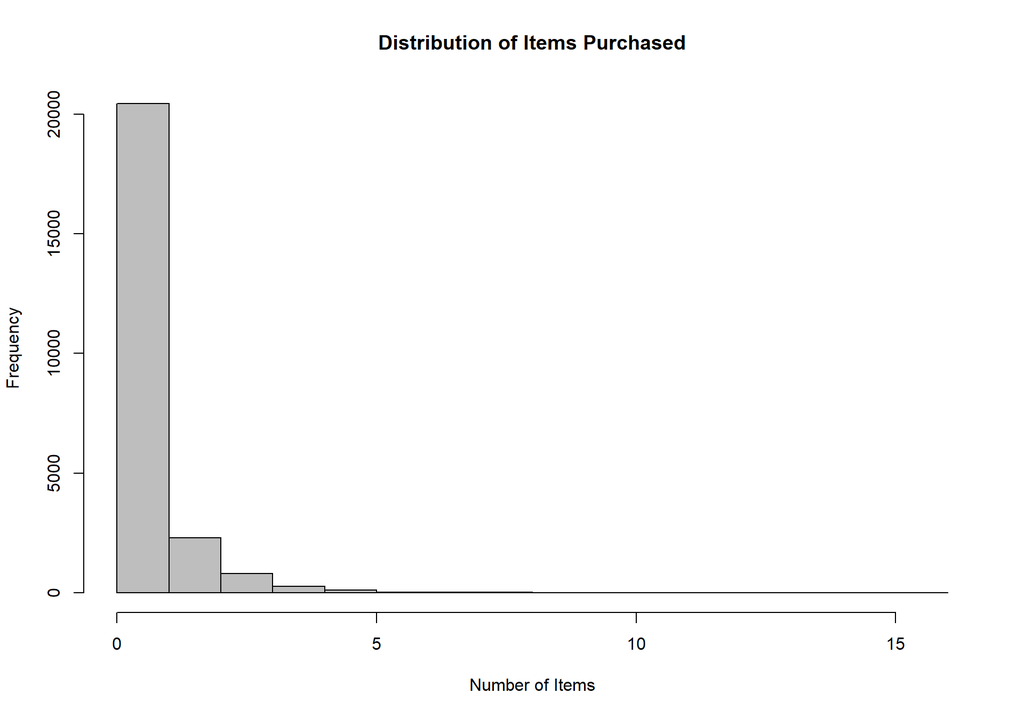

```r
# Distribution of items purchased
hist(df$item, breaks = 20, col = "gray", border = "black",
     main = "Distribution of Items Purchased",
     xlab = "Number of Items",
     ylab = "Frequency")
```

Most households purchase zero items, confirming that the target variable is zero-inflated.

```r
# Purchase Proportion by gender
gender_table <- table(Gender = df$gender, Purchase = df$purchase)
prop.table(gender_table, margin = 1)
```

```
##       Purchase
## Gender         0         1
##      0 0.5893149 0.4106851
##      1 0.6085586 0.3914414
```

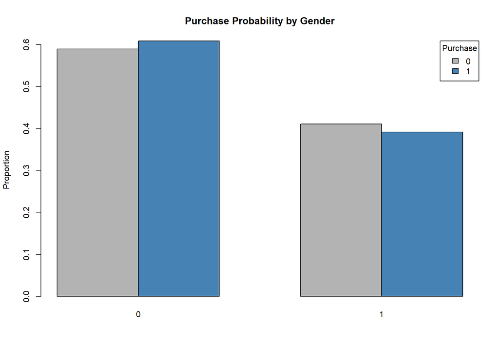

```r
barplot(prop.table(gender_table, margin = 1),
        beside = T, col = c("grey70", "steelblue"),
        legend = T,
        args.legend = list(title = "Purchase", x = "topright"),
        main = "Purchase Probability by Gender",
        ylab = "Proportion")
```

Both males and females purchase at similar rates.

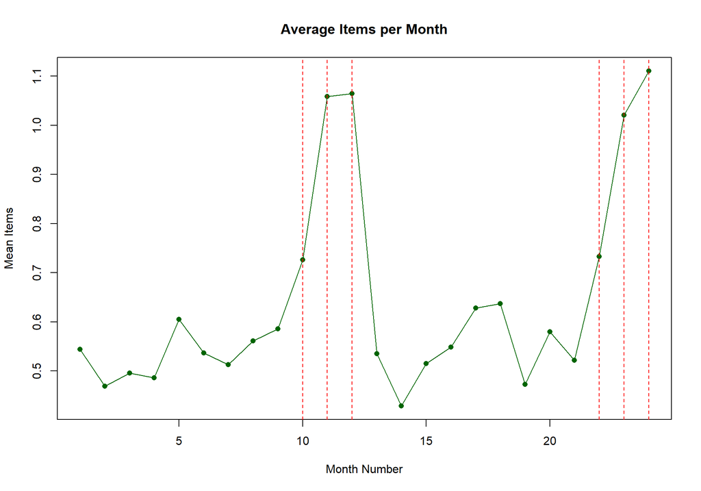

```r
# Average items per month - seasonality
mean_items <- tapply(df$item, df$monthnumb, mean)

plot(mean_items, type = "o", pch = 16, col = "darkgreen", main = "Average Items per Month",
     xlab = "Month Number", ylab = "Mean Items")
abline(v = c(10, 11, 12, 22, 23, 24), col = "red", lty = 2)
```

Purchase rises sharply in October, November and December indicating that there is seasonality in the data. This justifies including `xmas` as a dummy variable.

# 4. Empirical Models

In this section, we estimate three models of household purchase behavior, each representing a different way of handling the large number of zeros in the data.

## 4.1 Model 1: Zero-only

We first fit a **binary logistic model** to predict whether a purchase occurred. This captures the participation decision but ignores the number of items purchased.

```
## Family:  c("BI", "Binomial")
##
## Call:  gamlss(formula = purchase ~ catalogpromo + pricepromo + retailpromo +
##     married + gender + income + xmas + random(as.factor(id)),
##     family = BI, data = df, trace = F)
##
## Fitting method: RS()
##
## ------------------------------------------------------------------
## Mu link function:  logit
## Mu Coefficients:
##                Estimate Std. Error t value Pr(>|t|)
## (Intercept)  -1.454e+00  4.780e-02 -30.410  < 2e-16 ***
## catalogpromo  7.254e-02  5.076e-03  14.292  < 2e-16 ***
## pricepromo    1.838e+01  1.026e+02   0.179  0.85779
## retailpromo  -4.884e-02  3.805e-02  -1.283  0.19936
## married       5.565e-02  3.524e-02   1.579  0.11429
## gender        2.213e-02  3.812e-02   0.581  0.56158
## income        7.147e-07  2.311e-07   3.093  0.00198 **
## xmas          9.866e-01  3.358e-02  29.379  < 2e-16 ***
## ---
## Signif. codes:  0 '***' 0.001 '**' 0.01 '*' 0.05 '.' 0.1 ' ' 1
##
## ------------------------------------------------------------------
## NOTE: Additive smoothing terms exist in the formulas:
##  i) Std. Error for smoothers are for the linear effect only.
## ii) Std. Error for the linear terms may not be reliable.
## ------------------------------------------------------------------
## No. of observations in the fit:  24000
## Degrees of Freedom for the fit:  591.0343
##       Residual Deg. of Freedom:  23408.97
##                       at cycle:  2
##
## Global Deviance:     25314.73
##             AIC:     26496.8
##             SBC:     31275.79
```

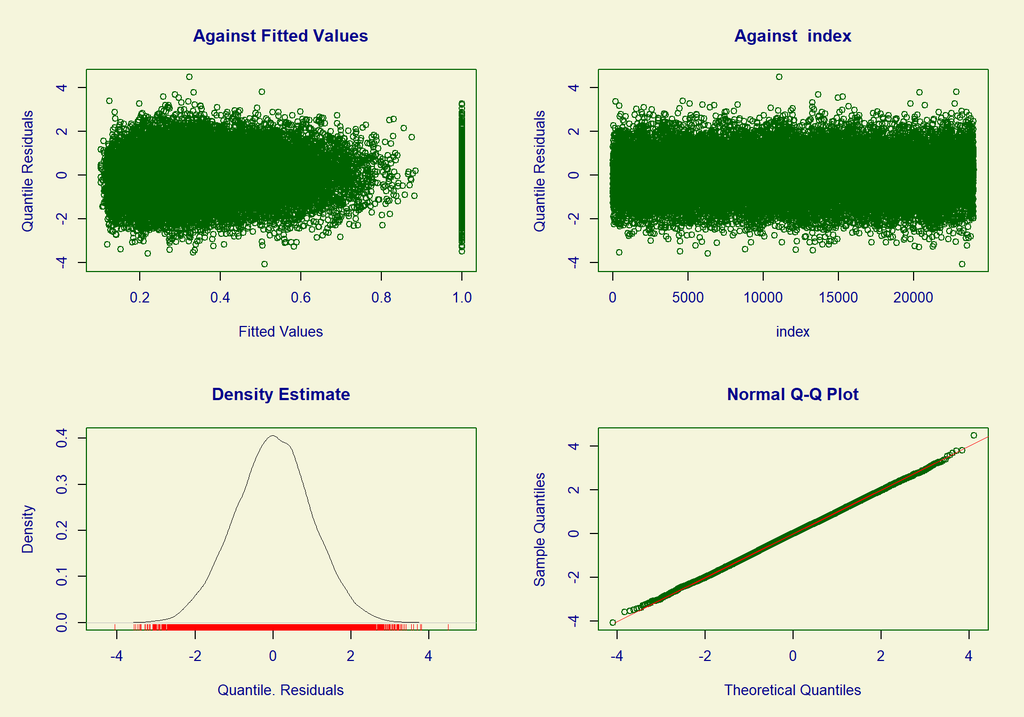

```
##   Summary of the Randomised Quantile Residuals
##                            mean   =  0.005270041
##                        variance   =  0.9808517
##                coef. of skewness  =  -0.01325437
##                coef. of kurtosis  =  2.982818
## Filliben correlation coefficient  =  0.999927
```

The results show which covariates influence the probability of purchase. However, this model cannot capture purchase intensity among buyers.

## 4.2 Model 2: Count-only

Next, we fit a **Negative Binomial model** on the raw item counts, including zeros. This accounts for overdispersion but forces zeros and positive counts to be explained by the same mechanism.

```
## Family:  c("NBI", "Negative Binomial type I")
##
## Call:  gamlss(formula = item ~ catalogpromo + pricepromo +
##     retailpromo + married + gender + income + xmas +
##     random(as.factor(id)), family = NBI, data = df,      trace = F)
##
## Fitting method: RS()
##
## ------------------------------------------------------------------
## Mu link function:  log
## Mu Coefficients:
##                Estimate Std. Error t value Pr(>|t|)
## (Intercept)  -1.167e+00  2.817e-02 -41.436  < 2e-16 ***
## catalogpromo  3.570e-02  2.650e-03  13.474  < 2e-16 ***
## pricepromo    8.341e-01  1.458e-02  57.199  < 2e-16 ***
## retailpromo  -3.840e-02  2.055e-02  -1.868 0.061750 .
## married       2.947e-02  2.045e-02   1.442 0.149445
## gender       -2.258e-02  2.311e-02  -0.977 0.328508
## income        4.779e-07  1.326e-07   3.604 0.000315 ***
## xmas          6.116e-01  1.817e-02  33.668  < 2e-16 ***
## ---
## Signif. codes:  0 '***' 0.001 '**' 0.01 '*' 0.05 '.' 0.1 ' ' 1
##
## ------------------------------------------------------------------
## Sigma link function:  log
## Sigma Coefficients:
##             Estimate Std. Error t value Pr(>|t|)
## (Intercept)  -2.2956     0.1028  -22.34   <2e-16 ***
## ---
## Signif. codes:  0 '***' 0.001 '**' 0.01 '*' 0.05 '.' 0.1 ' ' 1
##
## ------------------------------------------------------------------
## NOTE: Additive smoothing terms exist in the formulas:
##  i) Std. Error for smoothers are for the linear effect only.
## ii) Std. Error for the linear terms maybe are not accurate.
## ------------------------------------------------------------------
## No. of observations in the fit:  24000
## Degrees of Freedom for the fit:  661.4043
##       Residual Deg. of Freedom:  23338.6
##                       at cycle:  10
##
## Global Deviance:     45489.45
##             AIC:     46812.26
##             SBC:     52160.25
```

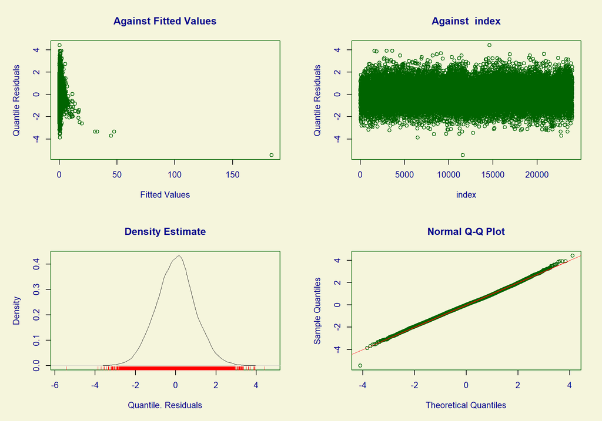

```
##   Summary of the Randomised Quantile Residuals
##                            mean   =  -0.002885873
##                        variance   =  0.9381419
##                coef. of skewness  =  0.03663983
##                coef. of kurtosis  =  3.241561
## Filliben correlation coefficient  =  0.9996005
```

## 4.3 Model 3: Hurdle model

Finally, we fit a **Zero-Inflated Negative Binomial (ZINBI)** model, which integrates the binary and count processes into a single framework:

- **Count component:**: expected number of items among buyers.
  $$\mu = E[Y \mid Y > 0], \quad
  \text{link: log}$$
- **Zero-inflation component:**: probability of purchase, or a structural component equivalent to binary logistic hurdle.
  $$\nu = P(Y = 0 \;
  \text{structural}), \quad \text{link: logit}$$

```
## Family:  c("ZINBI", "Zero inflated negative binomial type I")
##
## Call:  gamlss(formula = item ~ catalogpromo + pricepromo + retailpromo +
##     married + gender + income + xmas + random(as.factor(id)),
##     nu.formula = ~catalogpromo + pricepromo + retailpromo + married +
##         gender + income + xmas + random(as.factor(id)), family = ZINBI,
##     data = df)
##
## Fitting method: RS()
##
## ------------------------------------------------------------------
## Mu link function:  log
## Mu Coefficients:
##                Estimate Std. Error t value Pr(>|t|)
## (Intercept)  -1.135e-01  3.643e-02  -3.115  0.00184 **
## catalogpromo -1.510e-03  3.086e-03  -0.489  0.62453
## pricepromo    5.083e-01  7.533e-03  67.472  < 2e-16 ***
## retailpromo   7.976e-04  2.251e-02   0.035  0.97173
## married      -8.436e-03  2.380e-02  -0.355  0.72294
## gender       -2.672e-02  2.651e-02  -1.008  0.31351
## income        1.675e-07  1.590e-07   1.053  0.29214
## xmas          1.291e-01  2.094e-02   6.166 7.13e-10 ***
## ---
## Signif. codes:  0 '***' 0.001 '**' 0.01 '*' 0.05 '.' 0.1 ' ' 1
##
## ------------------------------------------------------------------
## Sigma link function:  log
## Sigma Coefficients:
##              Estimate Std. Error t value Pr(>|t|)
## (Intercept) -33.83741    0.00697   -4855   <2e-16 ***
## ---
## Signif. codes:  0 '***' 0.001 '**' 0.01 '*' 0.05 '.' 0.1 ' ' 1
##
## ------------------------------------------------------------------
## Nu link function:  logit
## Nu Coefficients:
##                Estimate Std. Error t value Pr(>|t|)
## (Intercept)   1.392e+00  7.709e-02  18.064   <2e-16 ***
## catalogpromo -1.664e-01  9.362e-03 -17.770   <2e-16 ***
## pricepromo   -2.511e+01  1.679e+03  -0.015   0.9881
## retailpromo   1.604e-01  5.904e-02   2.717   0.0066 **
## married      -8.536e-02  5.428e-02  -1.573   0.1158
## gender       -6.667e-02  5.915e-02  -1.127   0.2597
## income       -8.981e-07  3.622e-07  -2.479   0.0132 *
## xmas         -1.843e+00  7.163e-02 -25.729   <2e-16 ***
## ---
## Signif. codes:  0 '***' 0.001 '**' 0.01 '*' 0.05 '.' 0.1 ' ' 1
##
## ------------------------------------------------------------------
## NOTE: Additive smoothing terms exist in the formulas:
##  i) Std. Error for smoothers are for the linear effect only.
## ii) Std. Error for the linear terms may not be reliable.
## ------------------------------------------------------------------
## No. of observations in the fit:  24000
## Degrees of Freedom for the fit:  807.3287
##       Residual Deg. of Freedom:  23192.67
##                       at cycle:  20
##
## Global Deviance:     44824.9
##             AIC:     46439.56
##             SBC:     52967.46
```

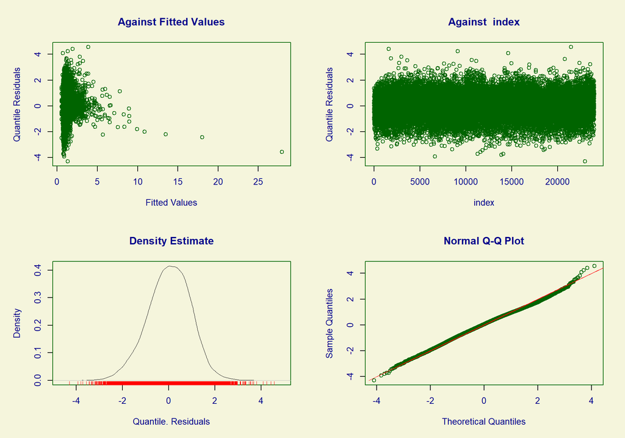

```
##   Summary of the Randomised Quantile Residuals
##                            mean   =  0.01956793
##                        variance   =  0.8723507
##                coef. of skewness  =  -0.1634804
##                coef. of kurtosis  =  3.185286
## Filliben correlation coefficient  =  0.9987376
```

This model explicitly separates the decision to buy from the number of items purchased once buying occurs, providing a natural hurdle interpretation.

# 5. Conclusion

This analysis compared three approaches to modeling household purchases:  
1. A **binary-only model (BI)**, which captures whether a purchase occurs but ignores purchase intensity.  
2. A **count-only model (NBI)**, which models the number of items purchased but forces zeros and positive counts to be explained by the same mechanism.  
3. A **hurdle model (ZINBI)**, which integrates the binary participation decision and the count intensity process within a single framework.

**In conclusion, the hurdle model is the most appropriate approach for this dataset, as it balances statistical fit with behavioral interpretability, making it the best tool for analyzing household purchase patterns in the presence of excess zeros.**